# One–Way analysis of variance (ANOVA) Using Jamovi

One–Way analysis of variance (ANOVA) Using Jamovi

## When to use a One-Way ANOVA

A **one-way analysis of variance (ANOVA)** is a statistical test that can be used to assess whether the mean value of some outcome variable is different between three or more groups.

The observations/measurements on the outcome variable must be Scale data, such as weight, where you might want to compare the mean weight of the population of several different countries. The groups must be independent of each other, for example each person’s weight measurement is included in only one country.

If your measurements are Ordinal, then consider a Kruskal Wallis test instead.

If you wish to compare just two groups, then you can use ANOVA, but a better simpler alternative is to use an independent samples t-test.

For more help on “What test do I need” go to the **sigma** website [statistical worksheets resources](https://libguides.coventry.ac.uk/c.php?g=712076&p=5146769) page.

## Example

A paper bag manufacturer investigated the impact of varying hardwood fibre concentrations (5%, 10%, 15%, and 20%) on the tensile strength of their products, measured in pounds per square Inch (psi). Six test specimens were produced at each concentration level, resulting in 24 bags being tested. The data shown below can be downloaded in a CSV file called hardwood.csv:

[figure not shown]

Source: Applied Statistics and Probability for Engineers - Montgomery and Runger

The research question aimed to determine if there existed a significant difference in mean tensile strengths among the four hardwood concentration levels. To address this, a one-way ANOVA was conducted, testing the following hypotheses:

H0: There is **no difference** in mean tensile strength between the four hardwood concentrations.

H1: There **is a difference** in mean tensile strength between at least two of the hardwood concentrations.

The data need to be entered in Jamovi as two columns. The first column, **Conc**, represents the independent or grouping variable, where 1 means 5% hardwood concentration, 2 means 10% hardwood concentration, and so on. The second column, **Strength**, contains all the tensile strength measurements.

## Using Jamovi

To perform the one-way ANOVA in Jamovi, from the **Analyses** Menu, click **ANOVA** then **ANOVA**:

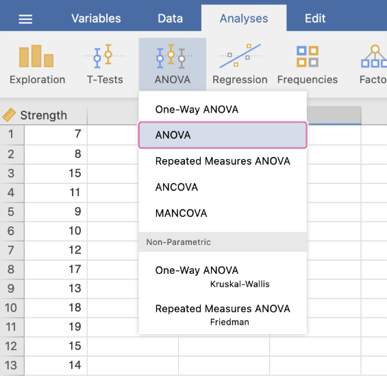

Move **Strength** (the outcome variable) into the **Dependent Variable** box. Next move **Conc** to the **Fixed Factors** box.

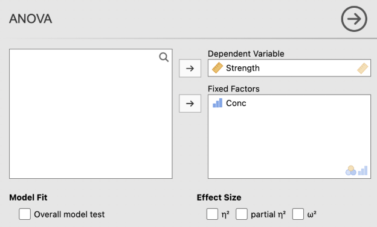

Open the **Estimated Marginal Means** tab. Move **Conc** to the **Term 1** box. Tick **Marginal means plots** and **Marginal means tables**.

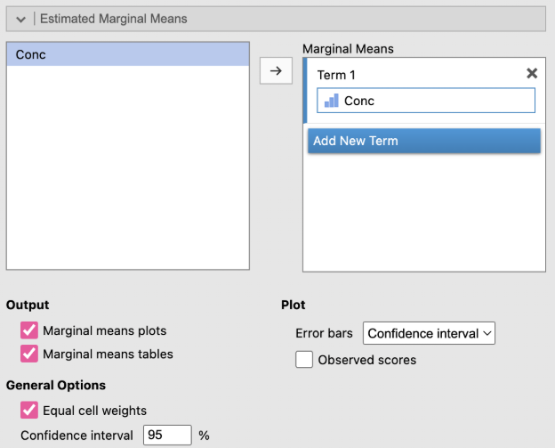

## Examining the Output

Using the main results produced by Jamovi you can see the following:

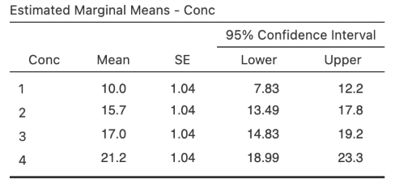

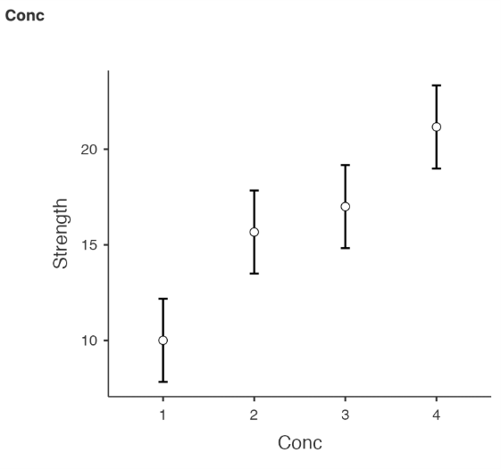

The **Estimated Marginal Means - Conc** table provides descriptive statistics for tensile strength for the different wood concentrations. The **Marginal Means Plot** show that in our samples, the higher the concentration, the higher the mean tensile strength, ranging from 10.0 psi at 5% to 21.2 psi at 20%. although we note there appears to be less difference in strength between the 10% concentration (15.7 psi) and the 15% concentration (17.0 psi).

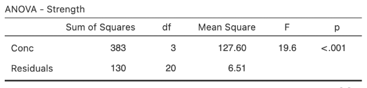

However, the ANOVA test only tells us that there is a difference somewhere, not where specifically, which is why we need to undergo post hoc tests to identify where the differences lie.

## Post-hoc tests

The nature of these differences can be explored further by performing **post hoc** tests to drill down into the results, but only if the ANOVA test has been found to be statistically significant, as in our case. Post-hoc tests identify any significant differences in mean scores between all possible pairs of the factor levels, in our case pairs of concentration levels. In effect they are variations on t-tests comparing each pair of means.

To obtain the post hoc tests, under the **Post Hoc Tests** tab, move ‘Conc’ to the **right-hand side** box and ensure **Tukey** under **Correction** is ticked:

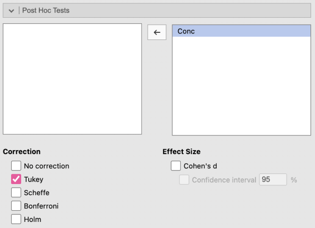

Because our factor has 4 levels, there are a total of 6 possible pairings:

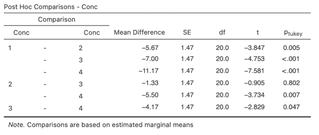

Careful examination of the Jamovi output indicates a statistically significant difference in mean strength between:

5% and 10%, 5% and 15%, 5% and 20% (p=0.005, p<0.001 and p<0.001, respectively), 10% and 20% (p=0.007), and 15% and 20% (p=0.047). However, there was no statistically significant difference between 10% and 15% (p=0.802).

## Further Work

### Normality

For the test to be valid it should be reasonable to assume that the measurements in each group are approximately normally distributed. If we have 30 or more measurements in each group, then we can safely make that assumption and need not check this any further.

Since we only had 6 measurements in each group, we need to do some further assessments. However, when we only have very small samples, it can sometimes be quite a challenge to determine whether the data in each group come from a normal distribution or not.

Hence, the best way to assess normality for one-way ANOVA is to repeat the main analysis but save what are called the **residuals**. The residuals are the differences between each observed value and the mean value for that group. We then need to check if this single column of residuals can be assumed to be normally distributed.

To save the residuals in Jamovi, open the **Save** tab in the **ANOVA** analysis and tick **Residuals**.

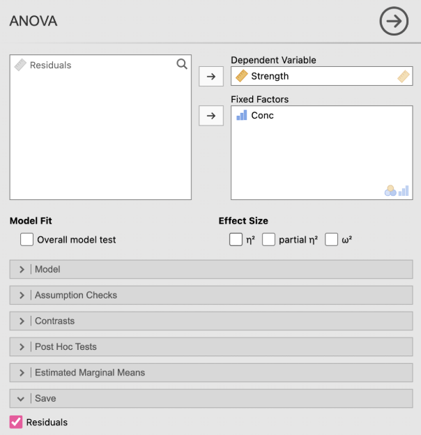

This will create a new variable called **Residuals** that can be found in the data and can be viewed by clicking on the Data Menu tab.

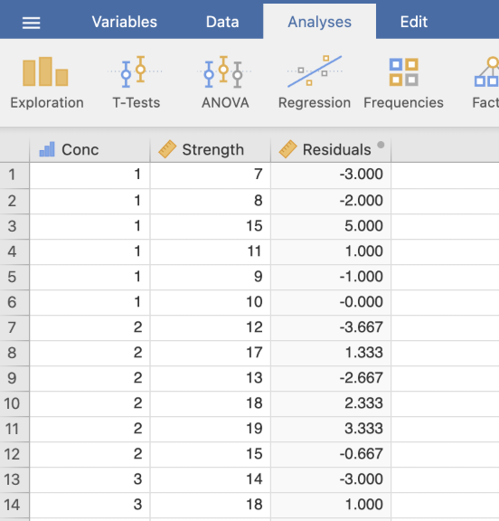

Then from the **Analyses** menu, click **Exploration**, then **Descriptives**. Move ‘Residuals’ to the **Variables** box:

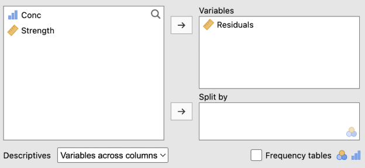

Under the **Plots** tab, tick **Histogram** to obtain a histogram.

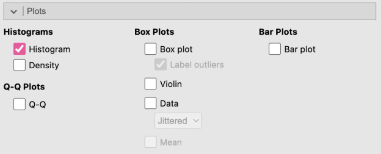

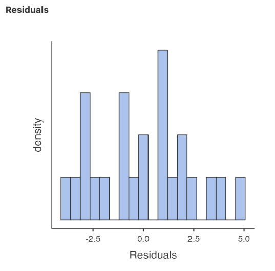

Normality could be judged by examining the shape of the histogram to see if it makes a roughly symmetric bell-shaped curve. However, small sample sizes tend to make the histogram look ‘jagged’, making it harder to discern normality by eye. It is probably better to assess normality using the **Shapiro-Wilk test**, which appears in the Jamovi output under **Assumption Checks**.

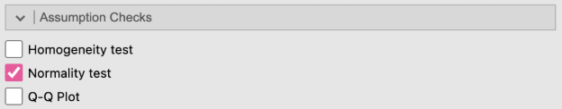

### Equal variances

The ANOVA test we undertook also assumes homogeneity (equality) of variance. This essentially means, can we assume the amount by which the tensile strength varies amongst bags with 10% concentration hardwood, is the same amount the strength of bags with 15% varies and so on?

Levene’s test is used in Jamovi to evaluate the homogeneity of variance assumption. In the **ANOVA** analysis, open the **Assumption Checks** tab and tick **Homogeneity test**.

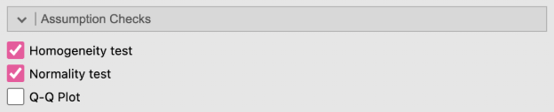

In the output we obtain the following table:

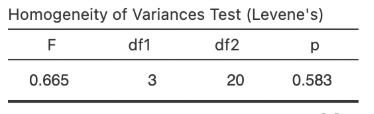

We examine the p-value. If this is above 0.05 then we can assume equality of variances. In our case p=0.583 so this assumption is fine in our case.

For more resources, see sigma.coventry.ac.uk Adapted from material developed by Coventry University